# Creating a Music Recommendation System using a Spotify Dataset

## Step 2: Visualize the Correlations

We can use ggplot2 to create a bar plot showing the correlation of each feature with the target variable “popularity.” This visualization makes it easier to identify which features have stronger relationships with the target variable.

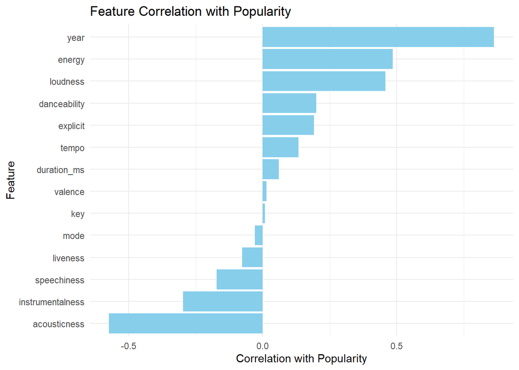

```r
library(ggplot2)

ggplot(cor_df, aes(x=reorder(feature, correlation), y=correlation)) +
  geom_bar(stat="identity", fill="skyblue") +
  coord_flip() +  # Flip coordinates for better readability
  theme_minimal() +
  labs(x = "Feature", y = "Correlation with Popularity", title = "Feature Correlation with Popularity")
```

##You can directly calculate the correlations and plot them without converting the dataframe to long format for this particular case:

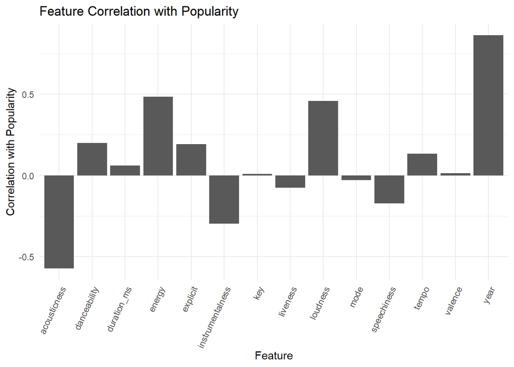

```r
library(dplyr)
library(ggplot2)

# Assuming 'data' is your dataframe and 'popularity' is the target variable
features <- c('acousticness', 'danceability', 'energy', 'instrumentalness',
              'liveness', 'loudness', 'speechiness', 'tempo', 'valence',
              'duration_ms', 'explicit', 'key', 'mode', 'year')

# Calculate correlations with 'popularity'
correlations <- sapply(data[features], function(feature) cor(feature, data$popularity, use = "complete.obs"))

# Convert correlations to a dataframe for plotting
cor_df <- data.frame(feature = names(correlations), correlation = correlations)

# Plot the correlations
ggplot(cor_df, aes(x = feature, y = correlation)) +
  geom_col() + # This is the correct geom for bar plots when data is already summarised
  theme_minimal() +
  theme(axis.text.x = element_text(angle = 65, hjust = 1)) +
  labs(x = "Feature", y = "Correlation with Popularity", title = "Feature Correlation with Popularity")
```

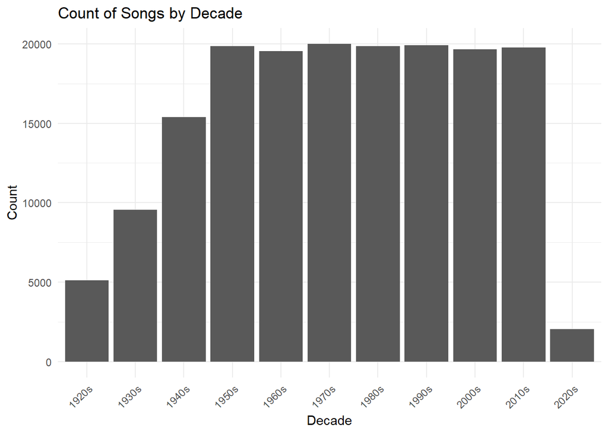

```r
library(ggplot2)

# Function to calculate decade
get_decade <- function(year) {
  paste0(as.integer(year / 10) * 10, "s")
}

# Add decade column
data$decade <- sapply(data$year, get_decade)

# Plot count of songs by decade
ggplot(data, aes(x = decade)) +
  geom_bar() +
  theme_minimal() +
  theme(axis.text.x = element_text(angle = 45, hjust = 1)) +
  labs(x = "Decade", y = "Count", title = "Count of Songs by Decade")
```

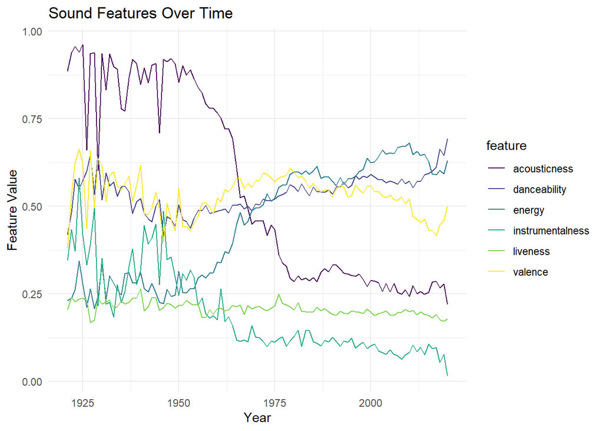

```r
library(ggplot2)
library(tidyr)
library(dplyr)

# Your sound features
sound_features <- c('acousticness', 'danceability', 'energy', 'instrumentalness', 'liveness', 'valence')

# Reshaping the data from wide to long format
year_data_long <- year_data %>%
  pivot_longer(cols = sound_features, names_to = "feature", values_to = "value")

# Plotting with ggplot2
ggplot(year_data_long, aes(x = year, y = value, color = feature)) +
  geom_line() +
  theme_minimal() +
  labs(title = "Sound Features Over Time", x = "Year", y = "Feature Value") +
  scale_color_viridis_d()
```

### Red: #FF0000 Green: #008000 Blue: #0000FF Yellow: #FFFF00 Orange: #FFA500 Purple: #800080 Cyan: #00FFFF Magenta: #FF00FF Lime: #00FF00 Pink: #FFC0CB

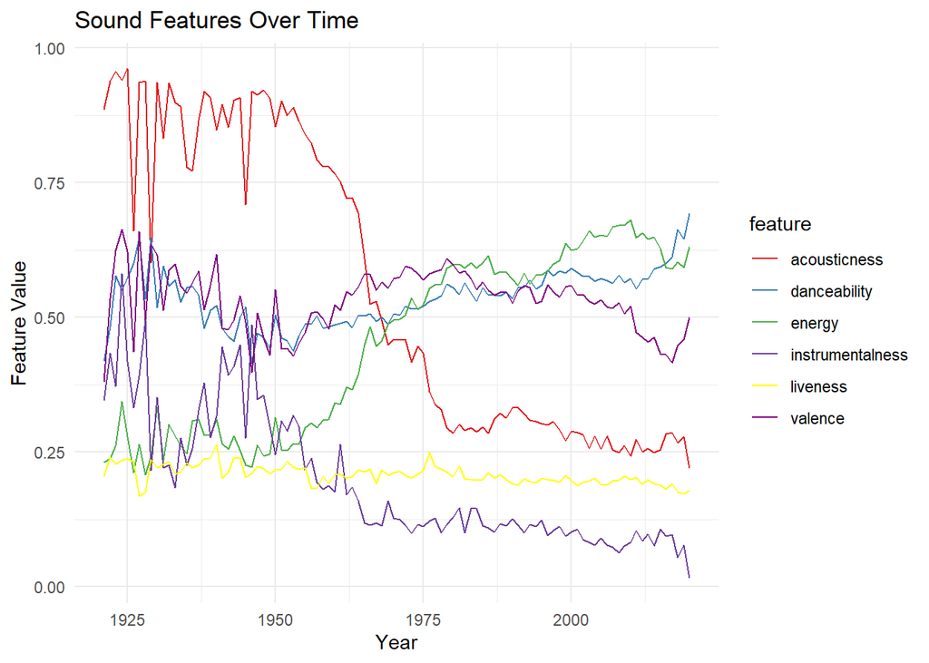

```r
library(ggplot2)
library(tidyr)
library(dplyr)

# Assuming year_data_long is already created from previous step

# Defining distinct colors for the first three features and another color for the rest
distinct_colors <- c(acousticness = "#E41A1C", # Red
                     danceability = "#377EB8", # Blue
                     energy = "#4DAF4A", # Green
                     instrumentalness = "#6A3D9A", # Purple for the rest (example)
                     liveness = "#FFFF00", # Yellow
                     valence = "#800080") #Purple

# Plotting with ggplot2
ggplot(year_data_long, aes(x = year, y = value, color = feature)) +
  geom_line() +
  scale_color_manual(values = distinct_colors) +
  theme_minimal() +
  labs(title = "Sound Features Over Time", x = "Year", y = "Feature Value")
```

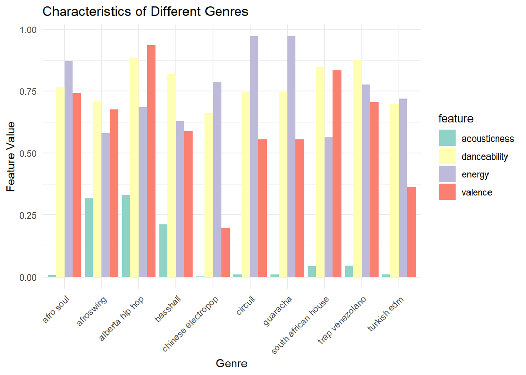

```r
library(dplyr)
library(ggplot2)
library(tidyr)

# Assuming 'genre_data' is your dataframe
top10_genres <- genre_data %>%
  arrange(desc(popularity)) %>%
  slice(1:10)

# Reshaping the data from wide to long format
top10_genres_long <- top10_genres %>%
  pivot_longer(cols = c('valence', 'energy', 'danceability', 'acousticness'),
               names_to = "feature", values_to = "value")

### Creating the Grouped Bar Chart

# Plot
ggplot(top10_genres_long, aes(x = genres, y = value, fill = feature)) +
  geom_bar(stat = "identity", position = "dodge") +
  theme_minimal() +
  theme(axis.text.x = element_text(angle = 45, hjust = 1)) +
  labs(x = "Genre", y = "Feature Value", title = "Characteristics of Different Genres") +
  scale_fill_brewer(palette = "Set3")
```

##Clustering Genres with K-Means

```r
if (!requireNamespace("factoextra", quietly = TRUE)) install.packages("factoextra")
if (!requireNamespace("Rtsne", quietly = TRUE)) install.packages("Rtsne")

library(factoextra)
library(Rtsne)
library(dplyr)
library(ggplot2)
```

```r
# Assuming 'genre_data' is your dataframe and contains numerical audio features only for this part

# Scaling the data
X_scaled <- scale(genre_data %>% select_if(is.numeric))

# Applying K-Means clustering
set.seed(123) # For reproducibility
kmeans_result <- kmeans(X_scaled, centers = 10, nstart = 25)

# Adding cluster results to the original data
genre_data$cluster <- as.factor(kmeans_result$cluster)
```

## Red: #E41A1C

```
Blue: #377EB8
Green: #4DAF4A
Purple: #984EA3
Orange: #FF7F00
Yellow: #FFFF33
Brown: #A65628
Pink: #F781BF
Grey: #999999
Light Blue: #A6CEE3
```

```r
# Remove duplicates from the scaled data
X_scaled_unique <- X_scaled[!duplicated(X_scaled), ]

# Applying K-Means clustering to the unique data
set.seed(123) # Ensuring reproducibility
kmeans_result <- kmeans(X_scaled_unique, centers = 10, nstart = 25)

# Since we removed duplicates, we need to ensure that the clustering results are correctly assigned back to the original data.
# This step depends on how you want to handle duplicates in your original dataset for clustering assignment.
# Here, we'll skip direct assignment and focus on t-SNE visualization with the unique dataset.

# Applying t-SNE to the unique scaled data
set.seed(123) # Ensuring reproducibility
tsne_result <- Rtsne(X_scaled_unique, dims = 2, perplexity = 30, verbose = TRUE)
```

[output not shown]

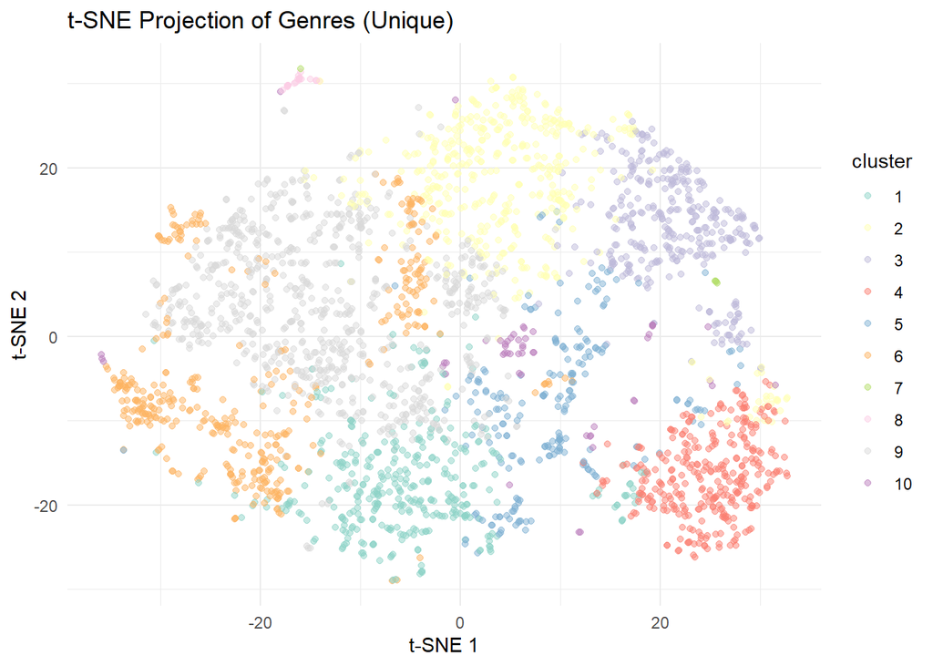

```r
# Creating a dataframe for plotting
projection <- data.frame(x = tsne_result$Y[,1], y = tsne_result$Y[,2])
projection$cluster = as.factor(kmeans_result$cluster)

# Plotting using ggplot2
ggplot(projection, aes(x = x, y = y, color = cluster)) +
  geom_point(alpha = 0.5) +
  theme_minimal() +
  labs(title = "t-SNE Projection of Genres (Unique)", x = "t-SNE 1", y = "t-SNE 2") +
  scale_color_brewer(palette = "Set3")
```

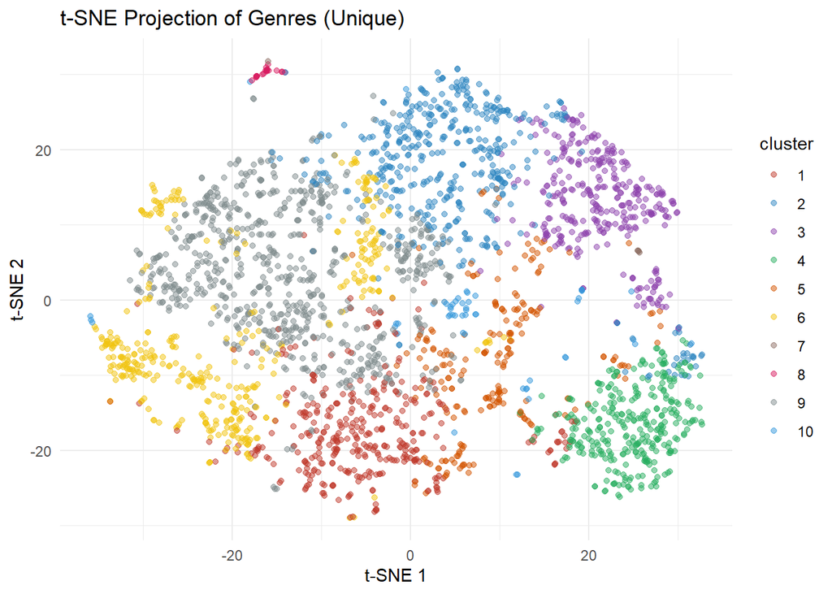

```r
# Define your custom, darker color palette
darker_colors <- c(
  '1' = '#C0392B', # Assuming your clusters are numbered and '1' represents a cluster for which you want dark red
  '2' = '#2E86C1',
  '3' = '#8E44AD',
  '4' = '#27AE60',
  '5' = '#D35400',
  '6' =  '#F1C40F', #Dark Yellow: #F1C40F (brighter but deeper)
  '7' = '#8D6E63', #Dark Brown: #8D6E63
  '8' = '#D81B60', #Dark Pink: #D81B60
  '9' = '#7F8C8D', #Dark Grey: #7F8C8D
  '10' = '#3498DB' #Deep Light Blue: #3498DB (more saturated rather than darker)
)

# Apply the custom colors to your plot
ggplot(projection, aes(x = x, y = y, color = cluster)) +
  geom_point(alpha = 0.5) +
  scale_color_manual(values = darker_colors) +
  theme_minimal() +
  labs(title = "t-SNE Projection of Genres (Unique)", x = "t-SNE 1", y = "t-SNE 2")
```

##Clustering Songs with K-Means

```r
if (!requireNamespace("factoextra", quietly = TRUE)) install.packages("factoextra")
if (!requireNamespace("cluster", quietly = TRUE)) install.packages("cluster")
if (!requireNamespace("ggplot2", quietly = TRUE)) install.packages("ggplot2")

library(factoextra)
library(cluster)
library(ggplot2)
```